# Explaining analyses conducted on Scott Creek Lagoon fish stable isotope data

Drought-induced sympatry of two salmonid species: Feeding ecology and trophic niches of potential competitors

Joseph D. Kiernan and Rosealea M. Bond

2026-09-23

# 1 Introduction

## 1.1 Summary and analysis of natural abundance stable isotope data

This document explains the analyses performed on the stable isotope samples collected in support of the manuscript titled, “Drought-induced sympatry of two salmonid species: Feeding ecology and trophic niches of potential competitors”. A separate R markdown file explains the analyses conducted on fish diet (stomach content) samples. Questions regarding these analyses or the R markdown should be directed to Dr. Joseph Kiernan at joseph.kiernan@noaa.gov.

### 1.1.1 Important note on software prerequisites and dependencies

To reproduce this analysis, you must install R, RStudio, and the **JAGS** software. JAGS is an external dependency required for the Bayesian modeling in the `SIBER` package. Because JAGS is an external system-level software, R cannot install it automatically for the user.

- Download JAGS here: [JAGS SourceForge](https://sourceforge.net/projects/mcmc-jags/files/JAGS/4.x/)

The code was tested and verified using JAGS version 4.3.1 (MacOS) and 4.3.2 (Windows).

## 1.2 Input data file

Data file: “Lagoon_fish_isotope.csv”.

This data set includes only age-1+ (yearling) coho salmon and steelhead. Carbon stable isotope values (header “d13C_corr”) are lipid corrected values; we mathematically lipid-corrected all fin clips with a C:N ratio > 3.5 (n = 77; 15.6% of the samples). Specifically, we followed the recommendation of Skinner et al. (2016) and applied the nonlinear normalization model developed by Kiljunen et al. (2006) with the Post et al. (2007) percentage lipid calculation.

1. Percentage Lipid Calculation (Post et al. 2007) utilizes the linear relationship between C:N and lipid content ($L$) proposed for aquatic animals:
   $$L = -20.54 + (7.24 \times C:N)$$
2. Nonlinear Normalization Model (Kiljunen et al. 2006) takes that $L$ value and applies the modified parameters ($D = 7.018$ and $I = 0.048$) to the McConnaughey & McRoy (1979) equation to calculate the isotopic shift: ($\Delta\delta^{13}C$):
   $$\Delta\delta^{13}C = 7.018 \times \left(0.048 +
   \frac{3.90}{1 + 287 / L}\right)$$
3. Final Correction
   $$\delta^{13}C_{corr}
   = \delta^{13}C_{raw} + \Delta\delta^{13}C$$
   This variable ($\delta^{13}C_{corr}$) is used in all subsequent analyses. See methods section of manuscript for additional details.

```r
# Create universal input and output directories
input_dir <- "Lagoon_SIA_Input_Data"
sia_dir <- "Lagoon_SIA_Results"

if (!dir.exists(input_dir)) {
  dir.create(input_dir)
}

# Create Results Directory and Analysis Subfolders
output_dirs <- c(
  sia_dir,
  file.path(sia_dir, "SIBER"),
  file.path(sia_dir, "NicheROVER"),
  file.path(sia_dir, "Figures"),
  file.path(sia_dir, "Tables")
)

for (dir in output_dirs) {
  if (!dir.exists(dir)) {
    dir.create(dir, recursive = TRUE)
  }
}

if (!dir.exists(sia_dir)) {
  dir.create(sia_dir)
}

# Read the data using file.path() and the input directory
data_full <- read.csv(file.path(input_dir, "Lagoon_fish_isotope.csv"))
# The full data set contains additional fisheries metadata which do not contribute to the analysis

# To list months of the study chronologically rather than alphabetically.
data_full$Month <- factor(data_full$Month, levels =c("Jun","Jul","Aug","Sep","Oct","Nov","Dec"), ordered = TRUE)

data<-subset(data_full, select=c(Month, Species, Length_mm, d13C_corr, d15N)) #should be 494 observations of 5 variables
# The reduced data set includes five variables of interest: (1) sample month; (2) fish species code; (3) fish fork length (mm); (4) fish d13C value; and (5) fish d15N value.
```

## 1.3 Summarize stable isotope data

Purpose: to summarize the stable isotope data for each salmonid species (Onki = coho salmon and Onmy = steelhead) by month. These data are presented, in part, in Table 4 of the manuscript.

```r
# Calculate summary metrics
isotope.fish.summary<-ddply(data, c("Month", "Species"), summarise,
          count = length(Species), #sample size
          mFL = round(mean(Length_mm),digits=1), #mean fork length in mm
          sdFL = round(sd(Length_mm),digits=1), #standard deviation fork length in mm
          mC = round(mean(d13C_corr), digits=1), #mean d13C in per mil
          sdC = round(sd(d13C_corr), digits=1),#std deviation d13C in per mil
          CR = round(max(d13C_corr)-min(d13C_corr), digits=1), #d13C range in per mil
          mN = round(mean(d15N), digits=1), #mean d15N in per mil
          sdN = round(sd(d15N), digits=1), #std deviation d15N in per mil
          NR = round(max(d15N)-min(d15N), digits=1)) #d15N range in per mil

colnames(isotope.fish.summary) <- c ("Month", "Salmonid species", "N", "Mean", "SD", "Mean", "SD", "C-Range", "Mean", "SD", "N-Range")

# Export the summary table to the Tables folder
write.csv(isotope.fish.summary, file.path(sia_dir, "Tables", "Isotope_Fish_Summary.csv"), row.names = FALSE)

# Create a kable with corrected headers and collapsed rows
isotope.fish.summary %>%
  kbl(caption = "Summary of monthly carbon and nitrogen stable isotope ratios for lagoon-rearing coho salmon (Onki) and steelhead (Onmy). These data appear, in part, in Table 4 of the manuscript") %>%
  kable_classic(font = "Cambria") %>%
  add_header_above(c(" " = 3,
                     "Fork length (mm)" = 2,
                     "$\\delta^{13}$C ($\\unicode{x2030}$)"= 3,
                     "$\\delta^{15}$N ($\\unicode{x2030}$)"= 3)) %>%
  collapse_rows(columns = 1, valign = "top")
```

Summary of monthly carbon and nitrogen stable isotope ratios for lagoon-rearing coho salmon (Onki) and steelhead (Onmy). These data appear, in part, in Table 4 of the manuscript

| Month | Salmonid species | N | Fork length (mm) Mean | Fork length (mm) SD | $\delta^{13}$C ($\unicode{x2030}$) Mean | $\delta^{13}$C ($\unicode{x2030}$) SD | $\delta^{13}$C ($\unicode{x2030}$) C-Range | $\delta^{15}$N ($\unicode{x2030}$) Mean | $\delta^{15}$N ($\unicode{x2030}$) SD | $\delta^{15}$N ($\unicode{x2030}$) N-Range |
| --- | --- | --- | --- | --- | --- | --- | --- | --- | --- | --- |
| Jun | Onki | 36 | 144.5 | 8.3 | -20.6 | 1.2 | 5.0 | 12.0 | 0.6 | 2.7 |
|  | Onmy | 56 | 155.6 | 21.2 | -21.3 | 1.4 | 7.0 | 11.8 | 0.6 | 3.2 |
| Jul | Onki | 24 | 152.5 | 15.3 | -22.2 | 1.0 | 4.1 | 12.7 | 0.7 | 3.0 |
|  | Onmy | 38 | 176.5 | 34.3 | -22.5 | 1.3 | 5.4 | 12.2 | 0.6 | 3.0 |
| Aug | Onki | 5 | 161.6 | 8.4 | -22.8 | 0.9 | 2.2 | 13.3 | 0.5 | 1.1 |
|  | Onmy | 47 | 178.6 | 20.7 | -23.5 | 0.9 | 4.6 | 12.3 | 0.6 | 3.2 |
| Sep | Onki | 14 | 163.1 | 8.3 | -24.7 | 1.5 | 4.7 | 12.9 | 0.6 | 2.2 |
|  | Onmy | 58 | 169.0 | 37.4 | -26.2 | 1.9 | 7.6 | 10.6 | 0.9 | 3.8 |
| Oct | Onki | 14 | 159.9 | 14.0 | -24.8 | 1.3 | 5.0 | 12.6 | 0.5 | 1.7 |
|  | Onmy | 62 | 170.5 | 41.2 | -27.0 | 1.7 | 6.8 | 10.6 | 0.8 | 3.7 |
| Nov | Onki | 15 | 167.0 | 9.8 | -27.2 | 1.6 | 5.6 | 12.3 | 0.5 | 2.1 |
|  | Onmy | 56 | 187.0 | 40.7 | -27.7 | 1.7 | 7.0 | 11.1 | 0.6 | 3.0 |
| Dec | Onki | 7 | 177.3 | 6.8 | -24.4 | 2.1 | 5.5 | 13.3 | 0.3 | 0.8 |
|  | Onmy | 62 | 205.8 | 39.0 | -25.5 | 2.1 | 9.1 | 12.2 | 0.7 | 3.9 |

## 1.4 Wilcoxon rank sum test contrasting stable isotope values derived for each salmonid species

```r
# Define the correct chronological order for the months
month_order <- c("Jun", "Jul", "Aug", "Sep", "Oct", "Nov", "Dec")

# Filter data and format
data_filtered <- data %>%
  filter(Month %in% month_order) %>%
  mutate(Month = factor(Month, levels = month_order))

data_long <- data_filtered %>%
  pivot_longer(
    cols = c("d13C_corr", "d15N"),
    names_to = "Isotope",
    values_to = "value"
  )

# Monthly tests and effect sizes
all_wilcox_tests <- data_long %>%
  group_by(Month, Isotope) %>%
  rstatix::wilcox_test(value ~ Species)

all_wilcox_eff <- data_long %>%
  group_by(Month, Isotope) %>%
  rstatix::wilcox_effsize(value ~ Species)

all_results <- all_wilcox_tests %>%
  # Corrected join parameters here
  left_join(all_wilcox_eff, by = c("Month", "Isotope", ".y.", "group1", "group2", "n1", "n2")) %>%
  mutate(Period = as.character(Month))

# Overall tests and effect sizes
overall_wilcox_tests <- data_long %>%
  group_by(Isotope) %>%
  rstatix::wilcox_test(value ~ Species)

overall_wilcox_eff <- data_long %>%
  group_by(Isotope) %>%
  rstatix::wilcox_effsize(value ~ Species)

overall_results <- overall_wilcox_tests %>%
  # Corrected join parameters here
  left_join(overall_wilcox_eff, by = c("Isotope", ".y.", "group1", "group2", "n1", "n2")) %>%
  mutate(Period = "Overall")

# Combine results and format for downstream code
full_results_df <- bind_rows(all_results, overall_results) %>%
  rstatix::add_significance(p.col = "p") %>%
  select(Period, Isotope, group1, group2, statistic, p, p.signif, effsize) %>%
  mutate(effsize = round(effsize, 3))

# Write results to the SIA folder
write_csv(full_results_df, file.path(sia_dir, "Tables", "Isotope_Wilcoxon_Results.csv"))
```

### 1.4.1 Summary table of results for Wilcoxon tests.

These results are presented in Supplemental Table S4 in the manuscript. Note: Effect sizes are typically interpreted as small (0.1 to < 0.3), moderate (0.3 to < 0.5), and large (> 0.5).

```r
# This chunk uses the full_results_df created in the previous chunk
# Reshape data (Pivot wider)
wide_results <- full_results_df %>%
  pivot_wider(
    id_cols = Period,
    names_from = Isotope,
    values_from = c(statistic, p, effsize),
    names_glue = "{Isotope}_{.value}"
  ) %>%
  dplyr::rename(Month = Period)

# Reorder rows (chronological)
month_order <- c("Jun", "Jul", "Aug", "Sep", "Oct", "Nov", "Dec", "Overall")
wide_results <- wide_results %>%
  mutate(Month = factor(Month, levels = month_order)) %>%
  arrange(Month)

# Format Carbon p-values
wide_results$d13C_corr_p <- cell_spec(
  format(round(wide_results$d13C_corr_p, 3), nsmall=3),
  bold = ifelse(wide_results$d13C_corr_p < 0.006, TRUE, FALSE),
  color = ifelse(wide_results$d13C_corr_p < 0.006, "#D55E00", "black")
)

# Format Nitrogen p-values
wide_results$d15N_p <- cell_spec(
  format(round(wide_results$d15N_p, 3), nsmall=3),
  bold = ifelse(wide_results$d15N_p < 0.006, TRUE, FALSE),
  color = ifelse(wide_results$d15N_p < 0.006, "#D55E00", "black")
)

# Create summary table and assign it to an object
wilcoxon_table_out <- wide_results %>%
  select(Month,
         d13C_corr_statistic, d13C_corr_effsize, d13C_corr_p,
         d15N_statistic, d15N_effsize, d15N_p) %>%
  kbl(
    caption = "Table S4. Summary of Wilcoxon rank-sum tests and effect sizes (r). Significant p-values after Bonferroni correction are highlighted.",
    col.names = c("Month", "W Stat", "Effect (r)", "p-value", "W Stat", "Effect (r)", "p-value"),
    digits = 3,
    escape = FALSE
  ) %>%
  kable_classic(font = "Cambria", full_width = FALSE) %>%
  add_header_above(c(" " = 1, "$\\delta^{13}$C ($\\unicode{x2030}$)" = 3, "$\\delta^{15}$N ($\\unicode{x2030}$)" = 3)) %>%
  column_spec(1, width = "2cm") %>%
  column_spec(2:7, width = "2.0cm")

# Save the fully formatted table
save_kable(wilcoxon_table_out, file = file.path(sia_dir, "Tables", "Table_S4_Wilcoxon_Formatted.html"))

# Print the table to the document
wilcoxon_table_out
```

Table S4. Summary of Wilcoxon rank-sum tests and effect sizes (r). Significant p-values after Bonferroni correction are highlighted.

| Month | $\delta^{13}$C ($\unicode{x2030}$) W Stat | $\delta^{13}$C ($\unicode{x2030}$) Effect (r) | $\delta^{13}$C ($\unicode{x2030}$) p-value | $\delta^{15}$N ($\unicode{x2030}$) W Stat | $\delta^{15}$N ($\unicode{x2030}$) Effect (r) | $\delta^{15}$N ($\unicode{x2030}$) p-value |
| --- | --- | --- | --- | --- | --- | --- |
| Jun | 1346 | 0.282 | 0.007 | 1170 | 0.135 | 0.196 |
| Jul | 514 | 0.106 | 0.409 | 696 | 0.440 | 0.000 |
| Aug | 171 | 0.230 | 0.101 | 223 | 0.454 | 0.000 |
| Sep | 593 | 0.314 | 0.008 | 808 | 0.674 | 0.000 |
| Oct | 737 | 0.466 | 0.000 | 865 | 0.662 | 0.000 |
| Nov | 503 | 0.139 | 0.245 | 779 | 0.600 | 0.000 |
| Dec | 274 | 0.136 | 0.261 | 411 | 0.464 | 0.000 |
| Overall | 30108 | 0.279 | 0.000 | 34864 | 0.439 | 0.000 |

## 1.5 Calculate total area (TA) and standard ellipse area corrected for small sample size (SEAc).

### 1.5.1 Create summary table of TA and SEAc metrics

These values contribute, in part, to table 4 in the manuscript

```r
# Create the final kable output and assign it to an object
TA_SEAc_table_out <- metrics.wide %>%
  knitr::kable(
    caption = "Table 4 (in part). Monthly total area and SEAc values for each salmonid species",
    digits = 1,
    col.names = col_names #Apply the inner column names
  ) %>%
  kable_classic(font = "Cambria", full_width = FALSE) %>%
  add_header_above(c(" " = 1, "Coho Salmon" = 2, "Steelhead" = 2)) %>%
  column_spec(1:5, width = "2cm")

# Save the fully formatted table to the Tables folder
save_kable(TA_SEAc_table_out, file = file.path(sia_dir, "Tables", "Table_4_TA_SEAc_Formatted.html"))

# Print the table to the document
TA_SEAc_table_out
```

Table 4 (in part). Monthly total area and SEAc values for each salmonid species

| Month | Coho Salmon TA | Coho Salmon SEAc | Steelhead TA | Steelhead SEAc |
| --- | --- | --- | --- | --- |
| Jun | 7.3 | 1.9 | 11.2 | 2.2 |
| Jul | 6.9 | 2.4 | 7.7 | 1.8 |
| Aug | 1.3 | 1.7 | 8.2 | 1.5 |
| Sep | 5.3 | 2.4 | 11.7 | 3.0 |
| Oct | 3.6 | 1.9 | 16.0 | 3.4 |
| Nov | 5.4 | 2.4 | 11.7 | 2.6 |
| Dec | 2.5 | 1.9 | 14.8 | 2.7 |
| Overall | 25.8 | 5.8 | 39.1 | 6.3 |

### 1.5.2 Generating stable isotope biplots for each time period.

These data are presented as Figure 2 in the manuscript.

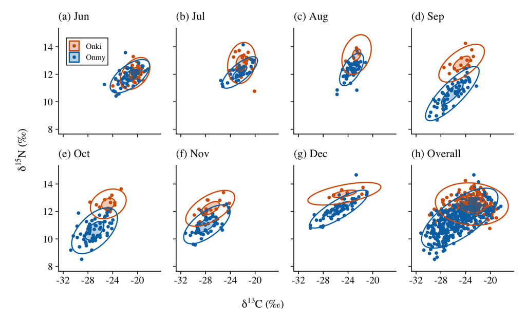

```r
# Define labels
plot_labels <- c("Jun"="(a) Jun", "Jul"="(b) Jul", "Aug"="(c) Aug", "Sep"="(d) Sep",
                 "Oct"="(e) Oct", "Nov"="(f) Nov", "Dec"="(g) Dec", "Overall"="(h) Overall")

# Plotting function (Base plot)
create_siber_biplot <- function(plot_data, plot_code) {
  x_lims <- c(-32, -17)
  y_lims <- c(8, 15)

  ggplot(plot_data, aes(x = iso1, y = iso2, col = group, fill = group)) +
    geom_point(size = 0.8) +
    stat_ellipse(geom = "polygon", alpha = 0.30, level = 0.40) +
    stat_ellipse(geom = "polygon", alpha = 0.0, level = 0.95) +
    scale_color_manual(values = c("Onki" = "#D55E00", "Onmy" = "#0072B2")) +
    scale_fill_manual(values = c("Onki" = "#D55E00", "Onmy" = "#0072B2")) +
    coord_cartesian(xlim = x_lims, ylim = y_lims) +
    labs(title = plot_labels[[plot_code]]) +
    theme_classic() +
    theme(
      panel.grid = element_blank(),
      plot.title = element_text(family = "serif", face = "plain", size = 10, hjust = 0),
      axis.title = element_blank(),
      axis.text = element_text(family = "serif", size = 9, color = "black"),
      axis.line = element_line(color = "black", linewidth = 0.3), # reduced line weight
      axis.ticks = element_line(color = "black", linewidth = 0.3)
    )
}

# Data prep
monthly_data_list <- split(siber.data, siber.data$community)
ordered_keys <- c("Jun", "Jul", "Aug", "Sep", "Oct", "Nov", "Dec")
plot_data_list <- monthly_data_list[ordered_keys]
plot_data_list$Overall <- siber.data

# Generate base plots
all_siber_plots <- imap(plot_data_list, create_siber_biplot)

# Apply conditional formatting (ticks & legend)
final_plot_list <- map2(all_siber_plots, names(all_siber_plots), function(p, name) {
  # Top Row: Jun, Jul, Aug, Sep -> Remove x-axis text
  if (name %in% c("Jun", "Jul", "Aug", "Sep")) {
    p <- p + theme(axis.text.x = element_blank())
  }

  # Not First Column: Jul, Aug, Sep, Nov, Dec, Overall -> Remove Y axis text
  if (!name %in% c("Jun", "Oct")) {
    p <- p + theme(axis.text.y = element_blank())
  }

  # Legend relocation and resizing
  if (name == "Jun") {
    p <- p + theme(
      # Shifted slightly right and down to prevent y-axis overlap
      legend.position = c(0.28, 0.78),
      legend.justification = c(0.5, 0.5),
      legend.background = element_rect(fill = "white", color = "black", linewidth = 0.3),
      legend.margin = margin(2, 2, 2, 2), # Tighter margins around the legend box
      legend.key.size = unit(0.7, "lines"), # Shrinks the colored boxes
      legend.text = element_text(family = "serif", size = 7), # Shrinks the legend text
      legend.title = element_blank(),
      text = element_text(family = "serif")
    )
  } else {
    # Hide legend for all other panels
    p <- p + theme(legend.position = "none")
  }

  return(p)
})

# Main Grid
main_grid <- wrap_plots(final_plot_list, ncol = 4, nrow = 2) &
  theme(text = element_text(family = "serif"))

# Global axes
y_expr <- expression(paste(delta^{15}, "N (\u2030)"))
x_expr <- expression(paste(delta^{13}, "C (\u2030)"))

# Set global axis font size to 10
y_grob <- textGrob(y_expr, rot = 90, gp = gpar(fontfamily = "serif", fontsize = 10))
x_grob <- textGrob(x_expr, gp = gpar(fontfamily = "serif", fontsize = 10))

# Assemble all
final_siber_panel <- (wrap_elements(y_grob) + main_grid + plot_layout(widths = c(1, 25))) /
                     wrap_elements(x_grob) +
                     plot_layout(heights = c(25, 1.1))

final_siber_panel
```

```r
ggsave(file.path(sia_dir, "Figures", "Figure_2.pdf"),
       width = 6.5, height = 3.97, units = "in", dpi = 800)
ggsave(file.path(sia_dir, "Figures", "Figure_2.tif"),
       width = 6.5, height = 3.97, units = "in", dpi = 800,
       device = "tiff", compression = "lzw")
```

Figure 2. Caption: Stable isotope biplots (δ13C versus δ15N) for juvenile coho salmon (*Oncorhynchus kisutch*; Onki) and steelhead (*O. mykiss*; Onmy), captured in the Scott Creek lagoon during each month of the study (Jun–Dec, panels a–g respectively). Panel h shows composited data from all months of the study. Points are individual fish samples and filled ellipses are the standard ellipse areas (corrected for small sample size; SEAc). Standard ellipse areas encompass approximately 40% of the isotopic data and represent the core isotopic niche for each species. The larger ellipses contain approximately 95% of the isotopic data for each species.

## 1.6 Calculating Bayesian Standard Ellipse Area (SEAb)

The previous calculations yielded point estimates (i.e., single value) of overlap based on the maximum likelihood estimated SEAc. To assess how reliable these data are, we need an associated measure of confidence/variance. This is achieved by calculating the Bayesian standard ellipse area (SEAb) and generating credible intervals.

```r
set.seed(2112)

# Run the SIBER model, default settings, uninformed priors
# SIBER mcmc model parameters
parms <- list()
parms$n.iter <- 2 * 10^4 # number of iterations to run the model
parms$n.burnin <- 1 * 10^3 # discard the first set of values
parms$n.thin <- 10 # thin the posterior by this many
parms$n.chains <- 2 # run this many chains

# SIBER mcmc model priors
priors <- list()
priors$R <- 1 * diag(2)
priors$k <- 2
priors$tau.mu <- 1.0E-3

# Run SIBER mcmc
ellipses.posterior <- siberMVN(siber.monthly.obj, parms, priors)
SEA.B <- siberEllipses(ellipses.posterior)
```

Here is a preliminary look at the distribution of ellipses for each population as a SIBER density plot. The gradations denote 95, 75 and 50% credible intervals. This plot does not include the overall (study-wide) pooled estimate which is generated later. This plot, in part, will be recreated later using ggplot to produce Figure 3 in the manuscript.

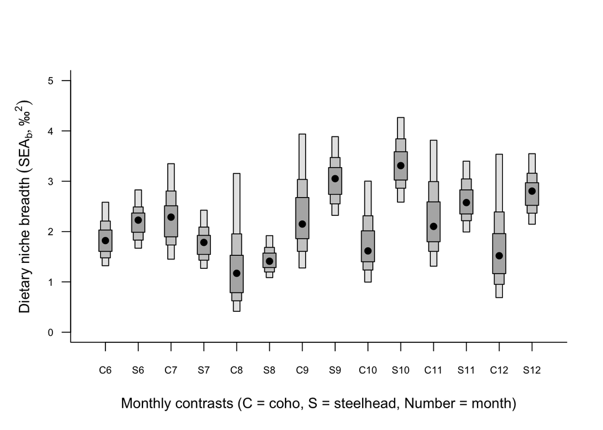

```r
# Save current settings
op <- par(no.readonly = TRUE)

# Set the global axis text size before the plot function
par(cex.axis = 0.7)

# SEA.B <- siberEllipses(ellipses.posterior)
siberDensityPlot(
                SEA.B,
                xlab = ("Monthly contrasts (C = coho, S = steelhead, Number = month)"),
                ylab = expression("Dietary niche breadth "(SEA[b],'\u2030' ^ 2) ),
                xticklabels = c("C6", "S6",
                                "C7", "S7",
                                "C8", "S8",
                                "C9", "S9",
                                "C10", "S10",
                                "C11", "S11",
                                "C12", "S12"),
                yticklabels = NULL,
                probs = c(50, 75, 95),
                bty = "L",
                las = 1,
                ylim = c(0,5),
                main = ""
                )
```

```r
# Restore original settings
par(op)

# The following line will add red x's for the ML estimated SEAc, if desired
#points(1:ncol(SEA.B), group.ML.monthly[3,], col="red", pch = "x", lwd = 2)
```

### 1.6.1 SEAb Credible Intervals

The following section of code extracts the mode and credibility intervals (SEAb) for each group and time period. Note, with an uninformative prior, the maximum likelihood estimate should correspond to the mode of the posterior distribution.

```r
# Examining the SEA.B credible intervals
cr.p <- c(0.50, 0.75, 0.95) # Vector of quantiles

colnames(SEA.B) <- c('Jun.Onki', 'Jun.Onmy',
                      'Jul.Onki', 'Jul.Onmy',
                      'Aug.Onki', 'Aug.Onmy',
                      'Sep.Onki', 'Sep.Onmy',
                      'Oct.Onki', 'Oct.Onmy',
                      'Nov.Onki', 'Nov.Onmy',
                      'Dec.Onki', 'Dec.Onmy'
                      ) #re-name columns in new list

# Calculate modes and credible intervals of SEA.B
SEA.B.modes <- lapply(
  as.data.frame(SEA.B),
  function(x,...){tmp <- hdrcde::hdr(x)$mode},
  prob = cr.p, all.modes = T) #vectors of the modes for each group's SEA.b
#SEA.B.modes

# Call to hdrcde:hdr using lapply()
SEA.B.credibles <- lapply(
  as.data.frame(SEA.B),
  function(x,...){tmp <- hdrcde::hdr(x)$hdr},
  prob = cr.p) #vectors of the credible intervals for each group's SEA.b
#SEA.B.credibles

# Save this output to the SIBER_Output directory
write.table(SEA.B.modes, file = file.path(sia_dir, "SIBER", "SEAb_Modes.csv"),
            append = F, sep = ',', row.names = T, col.names = NA)

write.table(SEA.B.credibles, file = file.path(sia_dir, "SIBER", "SEAb_Credible_Intervals.csv"),
            append = F, sep = ',', row.names = T, col.names = NA)
```

Although SIBER has a built-in SEAb plot (Siber.density.plot, created above), we will prepare the SIBER output for ggplot which is easier to customize and manipulate.

```r
# Draw posteriors for SIBER ellipse area for each "species.month" combination
SEA.B.2 <- SEA.B
colnames(SEA.B.2) <- colnames(group.ML.monthly)
SEA.B.2 <- as.data.frame(SEA.B.2)
SEA.B.2 <- melt(SEA.B.2)
SEA.B.2$combo <- SEA.B.2$variable
SEA.B.2 <- separate(data = SEA.B.2,
                    col = variable,
                    into = c("Month","Species"),
                    sep = "\\.",
                    extra = "merge")
SEA.B.2$Month <- factor(SEA.B.2$Month,
        levels = c('Jun','Jul','Aug','Sep','Oct','Nov','Dec')) #re-order months chronologically
```

Note: the warning “No id variables; using all as measure variables” is the precise structure we want for the data

Next we re-run the analysis for to generate the “overall” (all monthly data combined) estimates for each salmonid spp.

```r
#"Overall" SIBER model, default settings, uninformed priors

set.seed(2112)

# SIBER mcmc model parameters
parms <- list()
parms$n.iter <- 2 * 10^4 #number of iterations to run the model
parms$n.burnin <- 1 * 10^3 #discard the first set of values
parms$n.thin <- 10 #thin the posterior by this many
parms$n.chains <- 2 #run this many chains

# SIBER mcmc model priors
priors <- list()
priors$R <- 1 * diag(2)
priors$k <- 2
priors$tau.mu <- 1.0E-3

# Run SIBER mcmc
ellipses.posterior.overall <- siberMVN(siber.overall.obj, parms, priors)
# Calculate SEA.B for the "overall" data
SEA.B.overall <- siberEllipses(ellipses.posterior.overall)

# Rename the columns of the "overall" results using the ML object names
# Note: this assumes group.ML.overall was calculated earlier
overall_group_names <- colnames(group.ML.overall)
colnames(SEA.B.overall) <- overall_group_names
```

```r
# SEA.B.overall is the combined result from the chunk above.

# Combine the monthly and overall SEA.B results into a single object
SEA.B.full <- cbind(SEA.B, SEA.B.overall)

# Optional code: can reassign the column names of the full matrix for a final check
full_group_names <- c(colnames(SEA.B), colnames(SEA.B.overall))
colnames(SEA.B.full) <- full_group_names

# Additional data wrangling steps, using the new combined object
SEA.B.2 <- SEA.B.full # Use the full combined object, which includes 'Overall' data
SEA.B.2 <- as.data.frame(SEA.B.2)
SEA.B.2 <- melt(SEA.B.2)
SEA.B.2$combo <- SEA.B.2$variable
SEA.B.3 <- SEA.B.2

# The remaining code processes the 'Overall' data:
SEA.B.3 <- separate(data = SEA.B.3, col = variable, into = c("Month","Species"), sep = "\\.", extra = "merge")
SEA.B.3$Month <- factor(SEA.B.3$Month, levels = c('Jun','Jul','Aug','Sep','Oct','Nov','Dec','Overall')) #re-order months
```

Again, “No id variables; using all as measure variables” is the precise structure we want for the data.

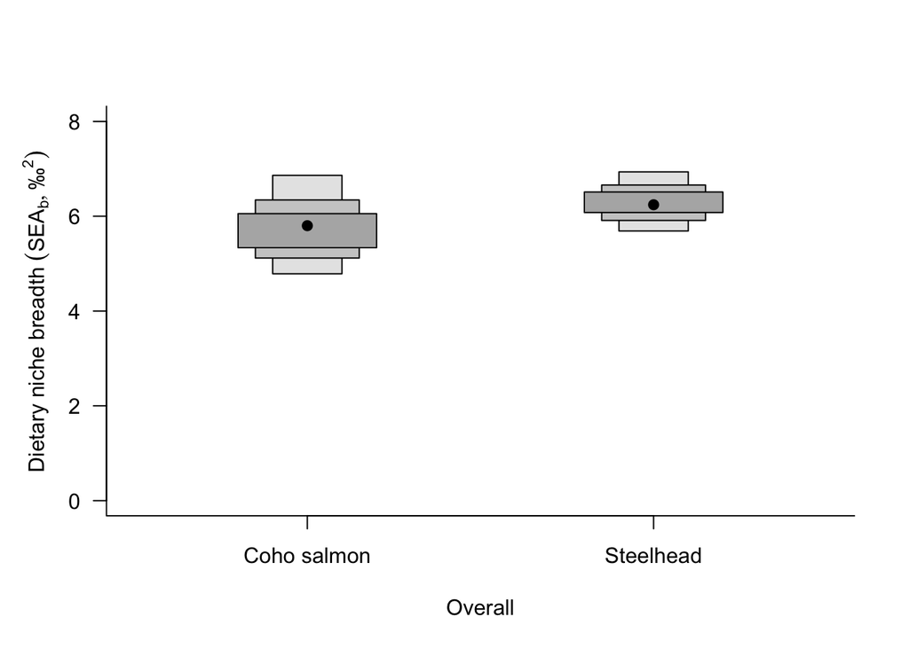

```r
siberDensityPlot(
               SEA.B.overall,
                xlab = c("Overall"),
                 ylab = expression("Dietary niche breadth " (SEA[b],'\u2030' ^2) ),
                 xticklabels = c("Coho salmon", "Steelhead"),
                 yticklabels = NULL,
                 probs = c(50, 75, 95),
                 bty = "L",
                 las = 1,
                 ylim = c(0,8),
                 main = ""
                 )
```

```r
#The following line of code (currently suppressed) will add red x's for the ML estimated SEAc if desired
#points(1:ncol(SEA.B), group.ML.overall[3,], col="red", pch = "x", lwd = 2)
```

```r
# Examining the SEA.B credible intervals
cr.p <- c(0.50, 0.75, 0.95) # vector of quantiles

# Calculate modes and credible intervals of SEA.B
SEA.B.overall.modes <- lapply(
  as.data.frame(SEA.B.overall),
  function(x,...){tmp <- hdrcde::hdr(x)$mode},
  prob = cr.p, all.modes = T) #vectors of the modes for each group's SEA.b
#SEA.B.overall.modes

# Call to hdrcde:hdr using lapply()
SEA.B.overall.credibles <- lapply(
  as.data.frame(SEA.B.overall),
  function(x,...){tmp <- hdrcde::hdr(x)$hdr},
  prob = cr.p) #vectors of the credible intervals for each group's SEA.b
#SEA.B.overall.credibles

# Save this output to the SIBER_Output directory
write.table(SEA.B.overall.modes, file = file.path(sia_dir, "SIBER", "SEAb_Overall_Modes.csv"),
            append = F, sep = ',', row.names = T, col.names = NA)

write.table(SEA.B.overall.credibles, file = file.path(sia_dir, "SIBER", "SEAb_Overall_Credible_Intervals.csv"),
            append = F, sep = ',', row.names = T, col.names = NA)
```

Here we combine SEA.B (monthly) and SEA.B.overall into SEA.B.full

```r
# Combination of monthly (SEA.B) and overall (SEA.B.overall) results into a full matrix
SEA.B.full <- cbind(SEA.B, SEA.B.overall)

# Define the *exact* column names for the combined matrix
full_col_names <- c('Jun.Onki', 'Jun.Onmy',
                    'Jul.Onki', 'Jul.Onmy',
                    'Aug.Onki', 'Aug.Onmy',
                    'Sep.Onki', 'Sep.Onmy',
                    'Oct.Onki', 'Oct.Onmy',
                    'Nov.Onki', 'Nov.Onmy',
                    'Dec.Onki', 'Dec.Onmy',
                    'Overall.Onki', 'Overall.Onmy')
colnames(SEA.B.full) <- full_col_names

#Melt the data for ggplot (creating SEA.B.3)
SEA.B.3 <- as.data.frame(SEA.B.full) %>%
  #Melt the wide data into long format
  melt(variable.name = "combo", value.name = "value") %>%
  #Split the 'combo' column into Month and Species
  separate(col = combo, into = c("Month", "Species"), sep = "\\.") %>%
  #Ensure chronological and 'Overall' order for Month factor
  mutate(Month = factor(Month,
                        levels = c('Jun','Jul','Aug','Sep','Oct','Nov','Dec','Overall'),
                        ordered = TRUE))
set.seed(123)

P_jun<- sum( SEA.B[,1] < SEA.B[,2] ) / nrow(SEA.B)
P_jul<- sum( SEA.B[,3] < SEA.B[,4] ) / nrow(SEA.B)
P_aug<- sum( SEA.B[,5] < SEA.B[,6] ) / nrow(SEA.B)
P_sep<- sum( SEA.B[,7] < SEA.B[,8] ) / nrow(SEA.B)
P_oct<- sum( SEA.B[,9] < SEA.B[,10] ) / nrow(SEA.B)
P_nov<- sum( SEA.B[,11] < SEA.B[,12] ) / nrow(SEA.B)
P_dec<- sum( SEA.B[,13] < SEA.B[,14] ) / nrow(SEA.B)
P_overall<- sum(SEA.B.overall[,1] < SEA.B.overall[,2] ) / nrow(SEA.B.overall)

prob_summary_df <- data.frame(
  Month = c("Jun", "Jul", "Aug", "Sep", "Oct", "Nov", "Dec", "Overall"),
  Probability = c(P_jun, P_jul, P_aug, P_sep, P_oct, P_nov, P_dec, P_overall)
)

prob_summary_df$Month <- factor(prob_summary_df$Month,
                                levels = c("Jun","Jul","Aug","Sep","Oct","Nov","Dec","Overall"),
                                ordered = TRUE)

prob_summary_df %>%
  kbl(
    caption = "Probability that the isotopic niche breadth (SEAb) of coho salmon (Onki) is less than steelhead (Onmy)",
    digits = 2,
    col.names = c("Month", "Probability")
  ) %>%
  kable_classic(font = "Cambria", full_width = FALSE) %>%

  add_header_above(c(" " = 1, "Pr(SEAb Onki < SEAb Onmy)" = 1))
```

Probability that the isotopic niche breadth (SEAb) of coho salmon (Onki) is less than steelhead (Onmy)

| Month | Pr(SEAb Onki < SEAb Onmy) Probability |
| --- | --- |
| Jun | 0.77 |
| Jul | 0.17 |
| Aug | 0.55 |
| Sep | 0.78 |
| Oct | 0.98 |
| Nov | 0.66 |
| Dec | 0.86 |
| Overall | 0.80 |

The above data are not included in the manuscript but confirm that the isotopic niche breadth of lagoon-rearing steelhead (Onmy) was generally greater than that of coho salmon (Onki).

### 1.6.2 Determining monthly and overall overlap in SIBER

Note: this chunk of code is VERY slow to run.

```r
set.seed(2564)
#Define the ellipses:

ellipse1 = "Jun.Onki"
ellipse2 = "Jun.Onmy"
ellipse3 = "Jul.Onki"
ellipse4 = "Jul.Onmy"
ellipse5 = "Aug.Onki"
ellipse6 = "Aug.Onmy"
ellipse7 = "Sep.Onki"
ellipse8 = "Sep.Onmy"
ellipse9 = "Oct.Onki"
ellipse10 = "Oct.Onmy"
ellipse11 = "Nov.Onki"
ellipse12 = "Nov.Onmy"
ellipse13 = "Dec.Onki"
ellipse14 = "Dec.Onmy"
ellipse15 = "Overall.Onki"
ellipse16 = "Overall.Onmy"

jun.bayes95.overlap <- bayesianOverlap(ellipse1, ellipse2, ellipses.posterior,
                                   draws = 1000, p.interval = 0.95, n = 100)
jul.bayes95.overlap <- bayesianOverlap(ellipse3, ellipse4, ellipses.posterior,
                                   draws = 1000, p.interval = 0.95, n = 100)
aug.bayes95.overlap <- bayesianOverlap(ellipse5, ellipse6, ellipses.posterior,
                                   draws = 1000, p.interval = 0.95, n = 100)
sep.bayes95.overlap <- bayesianOverlap(ellipse7, ellipse8, ellipses.posterior,
                                   draws = 1000, p.interval = 0.95, n = 100)
oct.bayes95.overlap <- bayesianOverlap(ellipse9, ellipse10, ellipses.posterior,
                                   draws = 1000, p.interval = 0.95, n = 100)
nov.bayes95.overlap <- bayesianOverlap(ellipse11, ellipse12, ellipses.posterior,
                                   draws = 1000, p.interval = 0.95, n = 100)
dec.bayes95.overlap <- bayesianOverlap(ellipse13, ellipse14, ellipses.posterior,
                                   draws = 1000, p.interval = 0.95, n = 100)
overall.bayes95.overlap <- bayesianOverlap(ellipse15, ellipse16, ellipses.posterior.overall,
                                   draws = 1000, p.interval = 0.95, n = 100)
```

```r
jun.bayes.prop.95.over <- (jun.bayes95.overlap[,3] / (jun.bayes95.overlap[,2] +
                                                jun.bayes95.overlap[,1] -
                                                jun.bayes95.overlap[,3]))
jul.bayes.prop.95.over <- (jul.bayes95.overlap[,3] / (jul.bayes95.overlap[,2] +
                                                jul.bayes95.overlap[,1] -
                                                jul.bayes95.overlap[,3]))
aug.bayes.prop.95.over <- (aug.bayes95.overlap[,3] / (aug.bayes95.overlap[,2] +
                                                aug.bayes95.overlap[,1] -
                                                aug.bayes95.overlap[,3]))
sep.bayes.prop.95.over <- (sep.bayes95.overlap[,3] / (sep.bayes95.overlap[,2] +
                                                sep.bayes95.overlap[,1] -
                                                sep.bayes95.overlap[,3]))
oct.bayes.prop.95.over <- (oct.bayes95.overlap[,3] / (oct.bayes95.overlap[,2] +
                                                oct.bayes95.overlap[,1] -
                                                oct.bayes95.overlap[,3]))
nov.bayes.prop.95.over <- (nov.bayes95.overlap[,3] / (nov.bayes95.overlap[,2] +
                                                nov.bayes95.overlap[,1] -
                                                nov.bayes95.overlap[,3]))
dec.bayes.prop.95.over <- (dec.bayes95.overlap[,3] / (dec.bayes95.overlap[,2] +
                                                dec.bayes95.overlap[,1] -
                                                dec.bayes95.overlap[,3]))
overall.bayes.prop.95.over <- (overall.bayes95.overlap[,3] / (overall.bayes95.overlap[,2] +
                                                overall.bayes95.overlap[,1] -
                                                overall.bayes95.overlap[,3]))
#jun.bayes.prop.95.over
#jul.bayes.prop.95.over
#aug.bayes.prop.95.over
#sep.bayes.prop.95.over
#oct.bayes.prop.95.over
#nov.bayes.prop.95.over
#dec.bayes.prop.95.over
#overall.bayes.prop.95.over
```

The next chunk creates a new data.frame (name = bayes.95.overlap.plotting) that combines the above posterior distributions (of proportional overlap) for data summary and visualization. These results are exploratory and not presented in the manuscript.

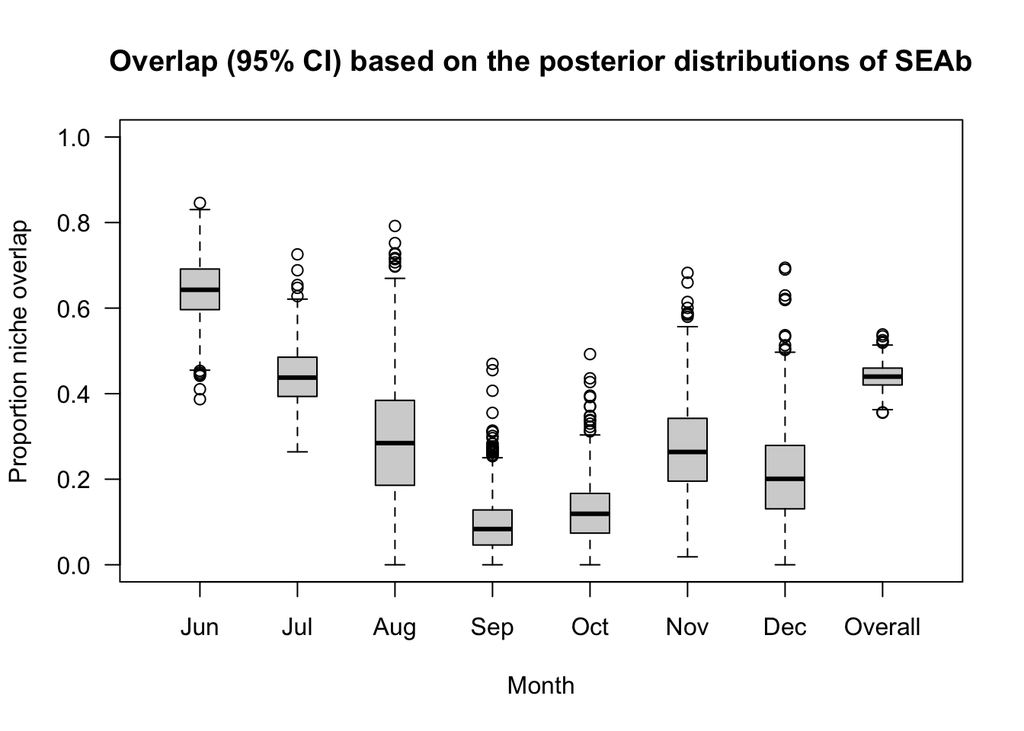

```r
bayes.95.overlap.plotting<-data.frame(jun.bayes.prop.95.over,
                                      jul.bayes.prop.95.over,
                                      aug.bayes.prop.95.over,
                                      sep.bayes.prop.95.over,
                                      oct.bayes.prop.95.over,
                                      nov.bayes.prop.95.over,
                                      dec.bayes.prop.95.over,
                                      overall.bayes.prop.95.over
                                      )
colnames(bayes.95.overlap.plotting)<-c("Jun","Jul","Aug","Sep","Oct","Nov","Dec","Overall")

#head(bayes.95.overlap.plotting)

boxplot(as.data.frame(bayes.95.overlap.plotting),
        main = "Overlap (95% CI) based on the posterior distributions of SEAb",
        xlab ="Month",
        ylab = "Proportion niche overlap",
        las =1,
        ylim = c(0, 1.0),
        boxwex = 0.4
)
```

Overlap values are presented as a proportion of the total area that overlaps in the two 95% ellipses and overlap values range from 0 when the ellipses are completely separated to 1.0 when the two ellipses fully overlap.

The next chunk of code extracts summary statistics for each distribution.

### 1.6.3 Mean, median and modal overlap values based on the posterior distributions of SEAB

These results are exploratory and not presented in the manuscript.

```r
df <- as.data.frame(bayes.95.overlap.plotting)

# Calculate the mean for each column (Month and Overall)
all_means <- sapply(df, mean, na.rm = TRUE)

# Calculate the median for each column (Month and Overall)
all_medians <- sapply(df, median, na.rm = TRUE)

# Find the peak of the density (the "mode") for each column (Month and Overall)
get_density_peak <- function(x, na.rm = TRUE) {
  if (na.rm) {
    x <- na.omit(x)
  }
  if (length(x) == 0) {
    return(NA)
  }
# Create density estimate
  d <- density(x)
# Return the 'x' value that has the highest 'y' value (the peak of their distribution)
  return(d$x[which.max(d$y)])
}

# Apply this function to every column
all_modes <- sapply(df, get_density_peak)

# Create the final table
results_table <- data.frame(
  Mean = all_means,
  Median = all_medians,
  Mode = all_modes
)

# Set the row names to be the column names (Months and Overall)
rownames(results_table) <- names(df)

# Convert row names to a column and store it as a clean data frame
final_overlap_stats <- results_table %>%
  rownames_to_column(var = "Month")

# Export the clean data frame to your centralized output folder
write.csv(final_overlap_stats, file.path(sia_dir, "SIBER", "SEAb_Posterior_Overlap_Stats.csv"), row.names = FALSE)

# Generate the HTML table for the document
final_overlap_stats %>%
  kbl(
    caption = "Summary statistics for the proportional niche overlap (SEAb, 95% CrI) between coho salmon and steelhead generated by SIBER.",
    digits = 2,
    col.names = c("Month", "Mean", "Median", "Mode")
  ) %>%
  kable_classic(font = "Cambria", full_width = TRUE)
```

Summary statistics for the proportional niche overlap (SEAb, 95% CrI) between coho salmon and steelhead generated by SIBER.

| Month | Mean | Median | Mode |
| --- | --- | --- | --- |
| Jun | 0.64 | 0.64 | 0.64 |
| Jul | 0.44 | 0.44 | 0.42 |
| Aug | 0.29 | 0.28 | 0.29 |
| Sep | 0.10 | 0.08 | 0.06 |
| Oct | 0.13 | 0.12 | 0.09 |
| Nov | 0.27 | 0.26 | 0.26 |
| Dec | 0.21 | 0.20 | 0.19 |
| Overall | 0.44 | 0.44 | 0.45 |

### 1.6.4 Creating Figure 3, Isotopic Diet Breadth

Here we make an alternative figure to the SIBER DENSITY PLOT that illustrates the mean SEAb value and credible intervals for each posterior distribution.

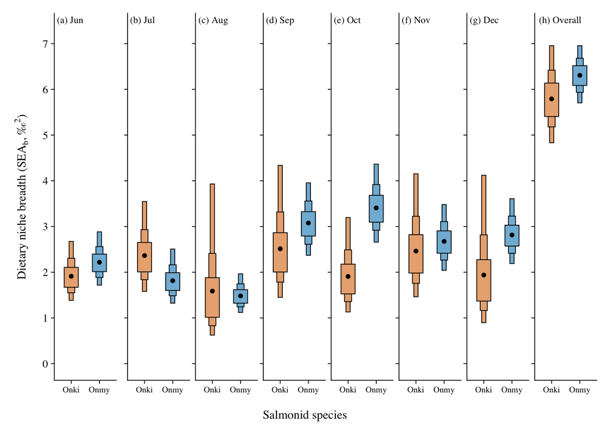

```r
# Pre-calculate the credible intervals
ci_95 <- SEA.B.3 %>% group_by(Month, Species) %>% mean_qi(value, .width = 0.95)
ci_75 <- SEA.B.3 %>% group_by(Month, Species) %>% mean_qi(value, .width = 0.75)
ci_50 <- SEA.B.3 %>% group_by(Month, Species) %>% mean_qi(value, .width = 0.50)

plot_labels <- c("Jun"="(a) Jun", "Jul"="(b) Jul", "Aug"="(c) Aug", "Sep"="(d) Sep",
                 "Oct"="(e) Oct", "Nov"="(f) Nov", "Dec"="(g) Dec", "Overall"="(h) Overall")
ordered_keys <- c("Jun", "Jul", "Aug", "Sep", "Oct", "Nov", "Dec", "Overall")

# Function to build individual panels (this forces L-shapes on every plot)
create_diet_plot <- function(month_key) {

  d95 <- ci_95 %>% filter(Month == month_key)
  d75 <- ci_75 %>% filter(Month == month_key)
  d50 <- ci_50 %>% filter(Month == month_key)

  p <- ggplot() +
    geom_crossbar(data = d95, aes(x = Species, y = value, ymin = .lower, ymax = .upper, fill = Species),
                  width = 0.15, color = "black", fatten = 0, linewidth = 0.3) +
    geom_crossbar(data = d75, aes(x = Species, y = value, ymin = .lower, ymax = .upper, fill = Species),
                  width = 0.25, color = "black", fatten = 0, linewidth = 0.3) +
    geom_crossbar(data = d50, aes(x = Species, y = value, ymin = .lower, ymax = .upper, fill = Species),
                  width = 0.50, color = "black", fatten = 0, linewidth = 0.3) +
    geom_point(data = d50, aes(x = Species, y = value), size = 1.2, color = "black") +

    scale_fill_manual(values = c("Onki" = "#EAAF80", "Onmy" = "#80B9D9")) +
    scale_y_continuous(limits = c(0, 7.3), breaks = seq(0, 8, 1)) +

    # Place panel tag inside the top-left corner
    annotate("text", x = -Inf, y = Inf, label = plot_labels[[month_key]],
             hjust = -0.10, vjust = 1.5, family = "serif", size = 2.8) +

    theme_classic() +
    theme(
      axis.title = element_blank(), # Removed local titles; we will use global ones
      axis.text.y = element_text(family = "serif", size = 9, color = "black"),
      axis.text.x = element_text(family = "serif", size = 7.0, color = "black"),
      axis.line = element_line(color = "black", linewidth = 0.3),# reduced weight of axis lines
      axis.ticks = element_line(color = "black", linewidth = 0.3),
      axis.ticks.length = unit(0.1, "cm"),

      legend.position = "none"
    )
  # Remove Y-axis numbers for all panels except the first one (Jun)
  if (month_key != "Jun") {
    p <- p + theme(axis.text.y = element_blank(),
                   plot.margin = margin(t = 5, r = 1, b = 5, l = 1, unit = "pt")
    )
  }

  return(p)
}

# Generate the list of plots and stitch them together in a 1x8 grid
all_diet_plots <- lapply(ordered_keys, create_diet_plot)
main_grid <- wrap_plots(all_diet_plots, ncol = 8, nrow = 1)

# Create global axes
y_expr <- expression(paste("Dietary niche breadth (", SEA[b], ", \u2030"^2, ")"))
y_grob <- textGrob(y_expr, rot = 90, gp = gpar(fontfamily = "serif", fontsize = 10))
x_grob <- textGrob("Salmonid species", gp = gpar(fontfamily = "serif", fontsize = 10))

# Assemble the final panel with patchwork
Diet.breadth.plot <- (wrap_elements(y_grob) + main_grid + plot_layout(widths = c(0.75, 25))) /
                     wrap_elements(x_grob) +
                     plot_layout(heights = c(25, 1.0))

Diet.breadth.plot
```

```r
ggsave(file.path(sia_dir, "Figures", "Figure_3.pdf"),
       width = 6.5, height = 3.97, units = "in", dpi = 800)
ggsave(file.path(sia_dir, "Figures", "Figure_3.tif"),
       width = 6.5, height = 3.97, units = "in", dpi = 800,
       device = "tiff", compression = "lzw")
```

Figure 3 legend: Estimates of dietary niche breadth (‰^2) for juvenile coho salmon (*Oncorhynchus kisutch*; Onki) and steelhead (*O. mykiss*; Onmy) captured in the Scott Creek lagoon. Species-specific estimates were generated for each month of the study (panels a–g) and an overall estimate (h) was produced from pooled data (all months combined) using posterior estimates of Bayesian standard ellipse areas (SEAb). Black dots represent the mean SEAb value after 20,000 iterations and box widths from wide to narrow represent 50, 75, and 95% credible intervals.

### 1.6.5 Generate table of SEAb Posterior Distribution Central Tendencies and Credible Intervals for Figure 3 data validation.

```r
# Re-use the density peak function from earlier in the script to calculate the Mode
get_density_peak <- function(x) {
  d <- density(x)
  return(d$x[which.max(d$y)])
}

# Extract all metrics from the SEA.B.3 posterior distributions
verification_table <- SEA.B.3 %>%
  group_by(Month, Species) %>%
  summarise(
    Mean = mean(value),
    Median = median(value),
    Mode = get_density_peak(value),
    # 50% CrI bounds (25th to 75th percentiles)
    CrI_50_low = quantile(value, 0.25),
    CrI_50_up = quantile(value, 0.75),
    # 75% CrI bounds (12.5th to 87.5th percentiles)
    CrI_75_low = quantile(value, 0.125),
    CrI_75_up = quantile(value, 0.875),
    # 95% CrI bounds (2.5th to 97.5th percentiles)
    CrI_95_low = quantile(value, 0.025),
    CrI_95_up = quantile(value, 0.975),
    .groups = "drop"
  ) %>%
  # Format the numbers to 2 decimal places
  mutate(across(where(is.numeric), ~ round(.x, 2)))

# Export the table to the SIA folder
write.csv(verification_table, file.path(sia_dir, "SIBER", "QC_Data_Validation.csv"), row.names = FALSE)

# Print the verification table
verification_table %>%
  kbl(
    caption = "SEAb Posterior Distribution Central Tendencies and Credible Intervals",
    align = "llrrrrrrrrr"
  ) %>%
  kable_classic(font = "Cambria", full_width = FALSE) %>%
  add_header_above(c(" " = 2, "Central Tendencies" = 3, "50% CrI" = 2, "75% CrI" = 2, "95% CrI" = 2))
```

SEAb Posterior Distribution Central Tendencies and Credible Intervals

| Month | Species | Central Tendencies Mean | Central Tendencies Median | Central Tendencies Mode | 50% CrI CrI_50_low | 50% CrI CrI_50_up | 75% CrI CrI_75_low | 75% CrI CrI_75_up | 95% CrI CrI_95_low | 95% CrI CrI_95_up |
| --- | --- | --- | --- | --- | --- | --- | --- | --- | --- | --- |
| Jun | Onki | 1.91 | 1.87 | 1.82 | 1.67 | 2.10 | 1.55 | 2.30 | 1.38 | 2.67 |
| Jun | Onmy | 2.22 | 2.20 | 2.23 | 2.01 | 2.40 | 1.89 | 2.56 | 1.72 | 2.88 |
| Jul | Onki | 2.36 | 2.31 | 2.29 | 2.01 | 2.65 | 1.84 | 2.93 | 1.58 | 3.55 |
| Jul | Onmy | 1.81 | 1.78 | 1.78 | 1.60 | 1.99 | 1.49 | 2.16 | 1.32 | 2.51 |
| Aug | Onki | 1.59 | 1.37 | 1.18 | 1.01 | 1.88 | 0.83 | 2.41 | 0.62 | 3.93 |
| Aug | Onmy | 1.48 | 1.46 | 1.41 | 1.32 | 1.62 | 1.24 | 1.75 | 1.12 | 1.96 |
| Sep | Onki | 2.51 | 2.40 | 2.16 | 2.00 | 2.86 | 1.78 | 3.32 | 1.45 | 4.34 |
| Sep | Onmy | 3.08 | 3.05 | 3.05 | 2.79 | 3.32 | 2.61 | 3.56 | 2.37 | 3.96 |
| Oct | Onki | 1.91 | 1.82 | 1.62 | 1.53 | 2.18 | 1.36 | 2.49 | 1.13 | 3.20 |
| Oct | Onmy | 3.41 | 3.36 | 3.31 | 3.09 | 3.68 | 2.92 | 3.92 | 2.66 | 4.36 |
| Nov | Onki | 2.46 | 2.34 | 2.10 | 1.98 | 2.82 | 1.76 | 3.22 | 1.46 | 4.15 |
| Nov | Onmy | 2.67 | 2.63 | 2.57 | 2.42 | 2.91 | 2.27 | 3.11 | 2.04 | 3.48 |
| Dec | Onki | 1.94 | 1.75 | 1.53 | 1.37 | 2.27 | 1.16 | 2.82 | 0.90 | 4.12 |
| Dec | Onmy | 2.81 | 2.79 | 2.80 | 2.57 | 3.03 | 2.41 | 3.23 | 2.19 | 3.61 |
| Overall | Onki | 5.79 | 5.76 | 5.80 | 5.41 | 6.14 | 5.18 | 6.42 | 4.83 | 6.95 |
| Overall | Onmy | 6.31 | 6.30 | 6.24 | 6.09 | 6.52 | 5.93 | 6.68 | 5.71 | 6.96 |

##NicheROVER - Determining isotopic niche overlap

This next section uses the R package “nicheROVER” to estimate dietary niche overlap between lagoon-rearing coho salmon and steelhead during each month of the study (Jun-Dec, 2015). We will run the model separately for each time period (month), and perform one run on all data pooled to create an “overall” estimate.

```r
# Clean environment and set seed
rm(list=ls())
graphics.off()
set.seed(2112)

# Re-add directory paths after the environment wipe
input_dir <- "Lagoon_SIA_Input_Data"
sia_dir <- "Lagoon_SIA_Results"
if (!dir.exists(sia_dir)) {
  dir.create(sia_dir)
}

summary_stats_list <- list() #To store table data

# Read the data
tryCatch({
  Fish.isotope.data <- read.csv(file.path(input_dir, "lagoon_fish_isotope.csv"), header = T)
}, error = function(e) {
  stop("Failed to read 'lagoon_fish_isotope.csv'. Make sure the file is in the 'Lagoon_SIA_Input_Data' directory.")
})

# Define analysis time periods
periods <- c("Jun", "Jul", "Aug", "Sep", "Oct", "Nov", "Dec", "Overall")

# Initialize lists to store results
# These store the ggplot objects and data frames for each sample period
plot_list <- list()
all_plot_data_list <- list()

# Define constants
clrs <- c("#D55E00", "#0072B2") # Onki = Vermilion, Onmy = Blue
nsamples <- 1000 #Number of posterior samples
```

The following chunk loops through each period, subsets the data, runs the `nicheROVER` analysis, saves all CSV and plot outputs, and stores the `ggplot` object for the final panel (figure 4 in the manuscript).

```r
for (period in periods) {

  cat(paste("\n--- Processing:", period, "---\n"))

# Subset and format data
  nicheROVER.df <- NULL #Ensure clean data frame

  if (period == "Overall") {
# For "Overall", subset only by species
    nicheROVER.df <- subset(Fish.isotope.data, Species %in% c("Onki", "Onmy"))
  } else {
# For specific months, subset by Month and Species
    nicheROVER.df <- subset(Fish.isotope.data, Month %in% period & Species %in% c("Onki", "Onmy"))
  }

# Reorder and rename columns for nicheROVER
  nicheROVER.df <- nicheROVER.df[c("Species", "d13C_corr", "d15N")]
  names(nicheROVER.df) <- c("species", "D13C", "D15N")

# Check data sufficiency
  species_counts <- table(nicheROVER.df$species)

# Check that we have both species and at least 3 samples for each (niw.post needs n > p)
  if (length(species_counts) < 2 || any(species_counts < 3)) {
    cat(paste("Skipping", period, "- insufficient data (n < 3) for one or both species.\n"))
    print(species_counts)
    next #Skip to the next iteration
  }

  cat("Sample sizes:\n")
  print(species_counts)

### Run nicheROVER analysis###

# Aggregate data for mean value check
  cat("Mean isotope values:\n")
  print(aggregate(nicheROVER.df[2:3], nicheROVER.df[1], mean))

# Create fish.par object (posterior draws)
  fish.par <- tapply(1:nrow(nicheROVER.df), nicheROVER.df$species,
                     function(ii) niw.post(nsamples = nsamples, X = nicheROVER.df[ii, 2:3]))

### Niche Overlap Calculation
# Calculate overlap for both 95% and 99%
  over.stat <- overlap(fish.par, nreps = nsamples, nprob = 1e4, alpha = c(.95, 0.99))

# Calculate and save mean overlap
  over.mean <- apply(over.stat, c(1:2, 4), mean) * 100
  cat("Mean Overlap (%):\n")
  print(round(over.mean, 2)) # Show 95%

  write.table(over.mean, file = file.path(sia_dir, "NicheROVER",
              paste0("Rover_Overlap_", period, ".csv")),
              append = F, sep = ',', row.names = T, col.names = NA)

# Calculate and save credible intervals
  over.cred <- apply(over.stat * 100, c(1:2, 4), quantile, prob = c(.025, .975), na.rm = TRUE)

write.table(over.cred, file = file.path(sia_dir, "NicheROVER",
            paste0("Rover_Cred_", period, ".csv")),
            append = F, sep = ',', row.names = T, col.names = NA)

# Niche size calculation
# Posterior distribution of niche size
  fish.size <- sapply(fish.par, function(spec) {
    apply(spec$Sigma, 3, niche.size, alpha = .95)
  })

write.table(fish.size, file = file.path(sia_dir, "NicheROVER",
            paste0("Rover_Niche_Size_", period, ".csv")),
            append = F, sep = ',', row.names = T, col.names = NA)

# Point estimate and standard error
  cat("Niche Size (est & se):\n")
  print(rbind(est = colMeans(fish.size), se = apply(fish.size, 2, sd)))

# Summary statistics for Kable
# Niche size
  size_est <- colMeans(fish.size)
  size_se <- apply(fish.size, 2, sd)

# Niche overlap (95%) - over.mean array is [Species A, Species B, Alpha]
  onki_on_onmy <- over.mean[1, 2, 1] # [Onki, Onmy, 95%]
  onmy_on_onki <- over.mean[2, 1, 1] # [Onmy, Onki, 95%]

# Get 95% CrIs from the 'over.cred' object
# Dim: [prob, from, to, alpha]
  onki_on_onmy_lowCI <- over.cred[1, 1, 2, 1] # prob=.025, from=Onki, to=Onmy, alpha=95%
  onki_on_onmy_highCI <- over.cred[2, 1, 2, 1] # prob=.975, from=Onki, to=Onmy, alpha=95%

  onmy_on_onki_lowCI <- over.cred[1, 2, 1, 1] # prob=.025, from=Onmy, to=Onki, alpha=95%
  onmy_on_onki_highCI <- over.cred[2, 2, 1, 1] # prob=.975, from=Onmy, to=Onki, alpha=95%

# Create a one-row data frame for this period
  period_stats <- data.frame(
    Period = period,
    Onki_Size_Est = size_est["Onki"],
    Onki_Size_SE = size_se["Onki"],
    Onmy_Size_Est = size_est["Onmy"],
    Onmy_Size_SE = size_se["Onmy"],
    Onki_on_Onmy_Overlap = onki_on_onmy,
    Onmy_on_Onki_Overlap = onmy_on_onki,

# Add new CrI columns
    Onki_on_Onmy_lowCI = onki_on_onmy_lowCI,
    Onki_on_Onmy_highCI = onki_on_onmy_highCI,
    Onmy_on_Onki_lowCI = onmy_on_onki_lowCI,
    Onmy_on_Onki_highCI = onmy_on_onki_highCI
  )

# Add to the master list
  summary_stats_list[[period]] <- period_stats

# Save the standard nicheROVER plots to a PDF for diagnostics
  pdf(file = file.path(sia_dir, "NicheROVER", paste0(period, "_nicheROVER_base_plots.pdf")), width = 7, height = 6)

# Parameter plots
  par(mar = c(4, 4, .5, .1) + .1, mfrow = c(1, 3))
  niche.par.plot(fish.par, col = clrs, plot.index = 1)
  niche.par.plot(fish.par, col = clrs, plot.index = 2)
  niche.par.plot(fish.par, col = clrs, plot.index = 1:2)
  legend("topleft", legend = names(fish.par), fill = clrs)

# 2D niche region plot
  par(mfrow = c(1, 1))
  fish.data <- tapply(1:nrow(nicheROVER.df), nicheROVER.df$species, function(ii) X = nicheROVER.df[ii, 2:3])
  niche.plot(niche.par = fish.par, niche.data = fish.data, pfrac = .05,
             iso.names = expression(delta^{15} * N, delta^{13} * C),
             col = clrs, xlab = expression("Isotope Ratio (\u2030)"))

# Overlap plot (using 95% alpha). This recalculates overlap with 1e3 nprob
  over.stat.plot <- overlap(fish.par, nreps = nsamples, nprob = 1e3, alpha = .95)
  overlap.plot(over.stat.plot, col = clrs, mean.cred.col = "black", equal.axis = TRUE,
               xlab = "Overlap Probability (%) -- Niche Region Size: 95%")

# Niche size boxplot
  boxplot(fish.size, col = clrs, pch = 16, cex = .5,
          ylab = "Niche Size", xlab = "Species")

  dev.off() #Close the PDF

# Prepare data for ggplot
# Use the 'over.stat.plot' object from the previous step (alpha = .95, nprob = 1e3)
  over.hist <- apply(over.stat.plot, 1:2, function(x) {
    if (any(is.na(x))) return(NULL)
    else { tmp <- x * 100 }
    tmp
  })

# Coho salmon (Onki) overlap on steelhead (Onmy)
  data_onki <- as.data.frame(over.hist[[1, 2]])
  colnames(data_onki) <- "Overlap"
  data_onki$Species <- "Onki"
  data_onki$Month <- period

# Steelhead (Onmy) overlap on coho salmon (Onki)
  data_onmy <- as.data.frame(over.hist[[2, 1]])
  colnames(data_onmy) <- "Overlap"
  data_onmy$Species <- "Onmy"
  data_onmy$Month <- period

# Combine and store
  combined_df <- rbind(data_onki, data_onmy)
  all_plot_data_list[[period]] <- combined_df

# Preparing ggplots
  # Standardized title lookup
  plot_labels <- c("Jun"="(a) Jun", "Jul"="(b) Jul", "Aug"="(c) Aug", "Sep"="(d) Sep",
                   "Oct"="(e) Oct", "Nov"="(f) Nov", "Dec"="(g) Dec", "Overall"="(h) Overall")

  #Base plot info
  p <- ggplot(data = combined_df, aes(x = Overlap, y = after_stat(scaled), fill = Species, color = Species)) +
    # FIX: Added linewidth = 0.3 to thin the borders around the density distributions
    geom_density(alpha = 0.5, linewidth = 0.3) +
    scale_fill_manual(values = c("Onki" = "#D55E00", "Onmy" = "#0072B2")) +
    scale_color_manual(values = c("black", "black")) + #Black for contrast
    scale_x_continuous(limits = c(0, 100), breaks = c(0, 20, 40, 60, 80, 100)) +
    scale_y_continuous(limits = c(0, 1), breaks = c(0, 0.5, 1)) +
    labs(title = plot_labels[[period]]) +
    theme_classic() +
    # FIX: Updated size = 0.5 to linewidth = 0.3 to thin the dashed/solid vertical mean lines
    geom_vline(xintercept = mean(subset(combined_df, Species == "Onki")$Overlap), linetype = "dashed", linewidth = 0.3) +
    geom_vline(xintercept = mean(subset(combined_df, Species == "Onmy")$Overlap), linetype = "solid", linewidth = 0.3) +
    theme(
      plot.title = element_text(family = "serif", hjust = 0, size = 10, face = "plain", margin = margin(b = 3, unit = "pt")),
      axis.text = element_text(family = "serif", size = 9, color = "black"),
      axis.title = element_blank(), #Removes all local axis titles
      axis.line = element_line(color = "black", linewidth = 0.3),
      axis.ticks = element_line(color = "black", linewidth = 0.3)
    )

 # Additional axes and margin logic
  top_row <- c("Jun", "Jul", "Aug", "Sep")
  bottom_row <- c("Oct", "Nov", "Dec", "Overall")
  left_col <- c("Jun", "Oct")
  right_col <- c("Sep", "Overall")

  # Set tight margins (2pt) for inner edges, and standard margins (5pt) for outer edges
  t_mar <- ifelse(period %in% top_row, 5, 2)
  b_mar <- ifelse(period %in% bottom_row, 12, 5)
  l_mar <- ifelse(period %in% left_col, 5, 2)
  r_mar <- ifelse(period %in% right_col, 5, 2)

  p <- p + theme(plot.margin = margin(t = t_mar, r = r_mar, b = b_mar, l = l_mar, unit = "pt"))

  # Remove X numbers for top row
  if(period %in% top_row) {
    p <- p + theme(axis.text.x = element_blank())
  }
  # Remove Y numbers for non-left columns
  if(!period %in% left_col) {
     p <- p + theme(axis.text.y = element_blank())
  }

# Legend logic (Jun Only) to match Figure 2
  if(period == "Jun") {
    p <- p + theme(
      # Pin the legend to the absolute top-left corner to avoid the density tail
      legend.position = c(0.02, 0.98),
      legend.justification = c(0, 1),
      legend.background = element_rect(fill = "white", color = "black", linewidth = 0.3),
      legend.margin = margin(2, 2, 2, 2),
      legend.title = element_blank(),
      legend.key.size = unit(0.7, "lines"),
      legend.text = element_text(family = "serif", size = 7),
      text = element_text(family = "serif")
    ) +
    # Override the legend keys to have a thin black border around the fill colors
    guides(fill = guide_legend(override.aes = list(color = "black", linewidth = 0.3)))

  } else {
    # Hide legends for all other panels
    p <- p + theme(legend.position = "none")
  }

  # Save the plot object to the list
  plot_list[[period]] <- p

  cat(paste("--- Finished:", period, "---\n"))
}
```

```
##
## --- Processing: Jun ---
## Sample sizes:
##
## Onki Onmy
##   36   56
## Mean isotope values:
##   species      D13C     D15N
## 1    Onki -20.58769 12.00850
## 2    Onmy -21.34626 11.84922
## Mean Overlap (%):
## , , alpha = 95%
##
##          Species B
## Species A Onki  Onmy
##      Onki   NA 93.28
##      Onmy 85.5    NA
##
## , , alpha = 99%
##
##          Species B
## Species A  Onki  Onmy
##      Onki    NA 98.16
##      Onmy 94.18    NA
##
## Niche Size (est & se):
##          Onki      Onmy
## est 10.752690 12.690847
## se   1.796741  1.693165
```

```
## --- Finished: Jun ---
##
## --- Processing: Jul ---
## Sample sizes:
##
## Onki Onmy
##   24   38
## Mean isotope values:
##   species     D13C     D15N
## 1    Onki -22.1881 12.73783
## 2    Onmy -22.5159 12.16780
## Mean Overlap (%):
## , , alpha = 95%
##
##          Species B
## Species A  Onki  Onmy
##      Onki    NA 67.76
##      Onmy 80.51    NA
##
## , , alpha = 99%
##
##          Species B
## Species A  Onki  Onmy
##      Onki    NA 79.39
##      Onmy 89.87    NA
##
## Niche Size (est & se):
##          Onki      Onmy
## est 12.890253 10.116431
## se   2.600147  1.669993
```

```
## --- Finished: Jul ---
##
## --- Processing: Aug ---
## Sample sizes:
##
## Onki Onmy
##    5   47
## Mean isotope values:
##   species      D13C     D15N
## 1    Onki -22.79848 13.34502
## 2    Onmy -23.45440 12.29332
## Mean Overlap (%):
## , , alpha = 95%
##
##          Species B
## Species A  Onki  Onmy
##      Onki    NA 66.04
##      Onmy 35.73    NA
##
## , , alpha = 99%
##
##          Species B
## Species A  Onki  Onmy
##      Onki    NA 84.27
##      Onmy 49.57    NA
##
## Niche Size (est & se):
##         Onki     Onmy
## est 5.862450 8.431277
## se  2.833773 1.242402
```

```
## --- Finished: Aug ---
##
## --- Processing: Sep ---
## Sample sizes:
##
## Onki Onmy
##   14   58
## Mean isotope values:
##   species      D13C     D15N
## 1    Onki -24.69965 12.87064
## 2    Onmy -26.18791 10.56873
## Mean Overlap (%):
## , , alpha = 95%
##
##          Species B
## Species A Onki Onmy
##      Onki   NA 9.04
##      Onmy 6.61   NA
##
## , , alpha = 99%
##
##          Species B
## Species A  Onki  Onmy
##      Onki    NA 23.33
##      Onmy 14.74    NA
##
## Niche Size (est & se):
##          Onki     Onmy
## est 12.506342 17.11389
## se   3.441869  2.31312
```

```
## --- Finished: Sep ---
##
## --- Processing: Oct ---
## Sample sizes:
##
## Onki Onmy
##   14   62
## Mean isotope values:
##   species      D13C     D15N
## 1    Onki -24.78876 12.59968
## 2    Onmy -26.96184 10.60994
## Mean Overlap (%):
## , , alpha = 95%
##
##          Species B
## Species A Onki  Onmy
##      Onki   NA 29.04
##      Onmy 9.64    NA
##
## , , alpha = 99%
##
##          Species B
## Species A  Onki  Onmy
##      Onki    NA 62.62
##      Onmy 17.22    NA
##
## Niche Size (est & se):
##         Onki      Onmy
## est 9.782447 19.670739
## se  2.850519  2.555473
```

```
## --- Finished: Oct ---
##
## --- Processing: Nov ---
## Sample sizes:
##
## Onki Onmy
##   15   56
## Mean isotope values:
##   species      D13C     D15N
## 1    Onki -27.16581 12.27203
## 2    Onmy -27.69017 11.07184
## Mean Overlap (%):
## , , alpha = 95%
##
##          Species B
## Species A  Onki  Onmy
##      Onki    NA 48.44
##      Onmy 34.67    NA
##
## , , alpha = 99%
##
##          Species B
## Species A  Onki  Onmy
##      Onki    NA 72.69
##      Onmy 52.66    NA
##
## Niche Size (est & se):
##         Onki      Onmy
## est 12.26833 15.236333
## se   3.39507  2.074307
```

```
## --- Finished: Nov ---
##
## --- Processing: Dec ---
## Sample sizes:
##
## Onki Onmy
##    7   62
## Mean isotope values:
##   species      D13C     D15N
## 1    Onki -24.39886 13.29980
## 2    Onmy -25.50665 12.18746
## Mean Overlap (%):
## , , alpha = 95%
##
##          Species B
## Species A  Onki  Onmy
##      Onki    NA 56.79
##      Onmy 15.74    NA
##
## , , alpha = 99%
##
##          Species B
## Species A  Onki  Onmy
##      Onki    NA 78.48
##      Onmy 22.68    NA
##
## Niche Size (est & se):
##         Onki      Onmy
## est 7.872720 15.937169
## se  3.167801  2.103208
```

```
## --- Finished: Dec ---
##
## --- Processing: Overall ---
## Sample sizes:
##
## Onki Onmy
##  115  379
## Mean isotope values:
##   species      D13C     D15N
## 1    Onki -23.11983 12.50872
## 2    Onmy -25.00250 11.47801
## Mean Overlap (%):
## , , alpha = 95%
##
##          Species B
## Species A  Onki  Onmy
##      Onki    NA 80.99
##      Onmy 64.23    NA
##
## , , alpha = 99%
##
##          Species B
## Species A  Onki  Onmy
##      Onki    NA 91.84
##      Onmy 76.96    NA
##
## Niche Size (est & se):
##          Onki      Onmy
## est 33.986018 37.455092
## se   3.091417  1.960104
```

```
## --- Finished: Overall ---
```

### 1.6.6 Create summary table of isotopic niche size and niche overlap

These data, in part, appear in Table S5 of the manuscript.

Isotopic niche size (mean & SE) and 95% niche overlap (mean & 95% credible interval) estimates generated by nicheROVER.

| Month | Mean niche Size (SE) Coho (Onki) | Mean niche Size (SE) Steelhead (Onmy) | Mean 95% Niche Overlap (95% CI) Coho on Steelhead | Mean 95% Niche Overlap (95% CI) Steelhead on Coho |
| --- | --- | --- | --- | --- |
| Jun | 10.75 (1.80) | 12.69 (1.69) | 93.3% (84.3-98.6) | 85.5% (72.9-95.1) |
| Jul | 12.89 (2.60) | 10.12 (1.67) | 67.8% (49.1-84.6) | 80.5% (64.4-94.3) |
| Aug | 5.86 (2.83) | 8.43 (1.24) | 66.0% (25.5-95.7) | 35.7% (10.6-75.3) |
| Sep | 12.51 (3.44) | 17.11 (2.31) | 9.0% (0.5-28.3) | 6.6% (0.5-26.1) |
| Oct | 9.78 (2.85) | 19.67 (2.56) | 29.0% (5.7-63.1) | 9.6% (2.3-28.0) |
| Nov | 12.27 (3.40) | 15.24 (2.07) | 48.4% (23.4-76.7) | 34.7% (13.2-69.7) |
| Dec | 7.87 (3.17) | 15.94 (2.10) | 56.8% (23.9-86.6) | 15.7% (5.9-34.6) |
| Overall | 33.99 (3.09) | 37.46 (1.96) | 81.0% (73.8-87.1) | 64.2% (55.3-72.9) |

### 1.6.7 Creating Figure 4, Probability of isotopic niche overlap

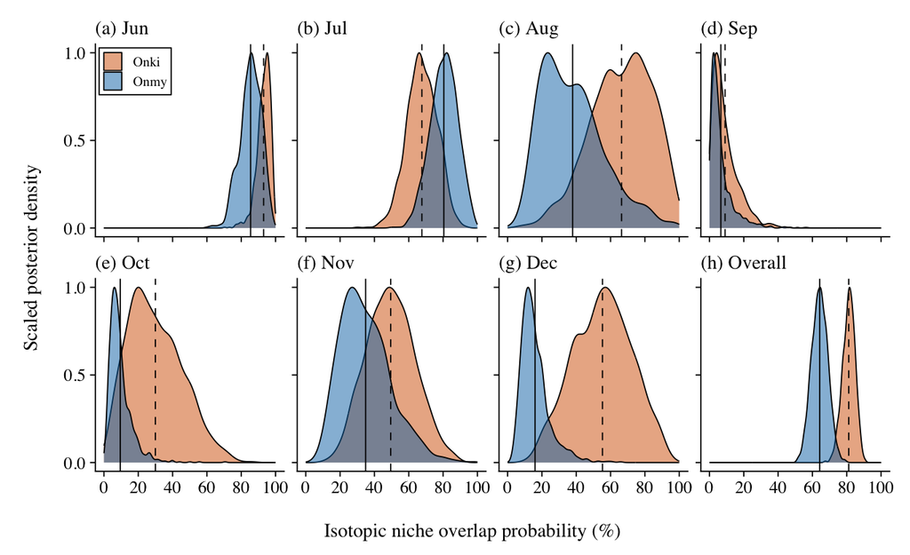

Figure 4. Bayesian estimates of isotopic niche overlap (95% region) between juvenile coho salmon (Oncorhynchus kisutch; Onki) and steelhead (O. mykiss; Onmy) captured in the Scott Creek lagoon. Overlap estimates were generated for each month of the study (panels a–g) and an overall estimate (h) was produced from pooled data (all months combined). The estimates were derived from δ13C and δ15N values and represent the probability that an individual coho salmon would be found within the isotopic niche region of steelhead, and vice versa. In each panel, dashed and solid vertical lines identify the mean isotopic niche overlap (%) for coho salmon and steelhead, respectively.